# M5: Path Reconstruction & Simulations

## 6 Coati Case Study

Let’s explore how the techniques and functions above can be used to study the white-nosed coati (*Nasua narica*), a small, semi-arboreal mammal in the Musteloidea superfamily. [This dataset](https://doi.org/10.5441/001/1.41076dq1) from Kays and Hirsch (2015) comprises of 2 individual coatis, Aleja and Anna, who were tracked in Barro Colorado Island, Panama. [The behavior of musteloids often limits their observation in the wild](https://doi.org/10.1093/oso/9780198759805.003.0008), and if inhabiting forested areas, canopy cover can block the signal from tracking devices used to observe them remotely or greatly increase the location error. We will focus on Aleja to fill gaps in the data and predict the most-likely path they used.

### 6.1 Data preparation

```r
# Load in the dataset from ctmm
data("coati")
summary(coati)
```

```
##       interval (min) period (day) longitude latitude
## Aleja       15.18333     39.91606 -79.84812 9.153453
## Anna        20.53333     14.99358 -79.84782 9.151313
```

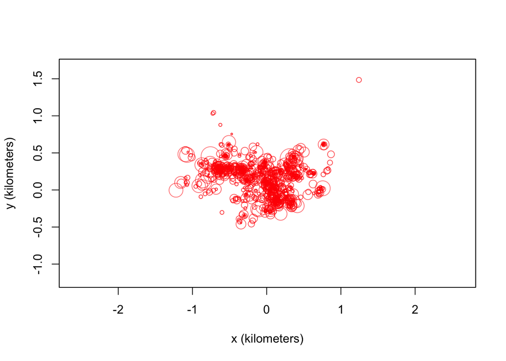

```r
projection(coati) <- median(coati)

# Subset to single individual
DATA <- coati[[1]]

# Visualize the data
plot(DATA, ylim = c(-1200,1650))
```

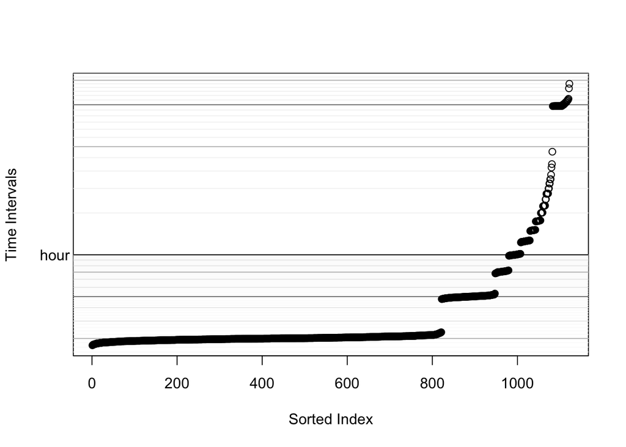

```r
dt.plot(DATA)  # diagnose the sampling schedule
```

```r
## There are gaps in the data
```

### 6.2 Model Selection

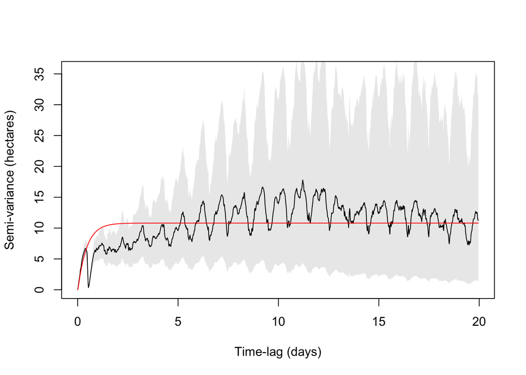

```r
# Generate the variogram and initial parameter guesses
vg <- variogram(DATA)
GUESS <- ctmm.guess(DATA, variogram = vg, interactive = FALSE)

# Visually inspect the fit
plot(vg, GUESS)
```

```r
# Model selection
FIT <- ctmm.select(data = DATA, CTMM = GUESS, trace = 3)
save(FIT, file = "Data/coati_aleja.rda")
```

```r
# Load saved model selection results
load(file = "Data/coati_aleja.rda")

# Summary of the fit
summary(FIT)  # OUF anisotropic model selected
```

```
## $name
## [1] "OUF anisotropic"
##
## $DOF
##      mean      area diffusion     speed
##  34.74326  52.94334 426.88426 718.71403
##
## $CI
##                                low       est      high
## area (square kilometers)  1.884726  2.516510  3.238212
## τ[position] (hours)       9.979953 13.604758 18.546122
## τ[velocity] (minutes)     7.416428  8.429695  9.581400
## speed (kilometers/day)    8.682494  9.011966  9.341274
## diffusion (hectares/day) 41.115067 45.312065 49.710102
```

### 6.3 Simulating Paths

Let’s simulate based on the original sampling times to see a potential trajectory realization. We can generate many simulations to see multiple potential paths taken under the same movement behaviors and conditions. Here, we are interested in seeing Aleja’s potential space use and where we may observe her, purely based on her movement behaviors. As such, the 2 simulations we generate here are based on Aleja’s best-fit model, but we do not input her known location points.

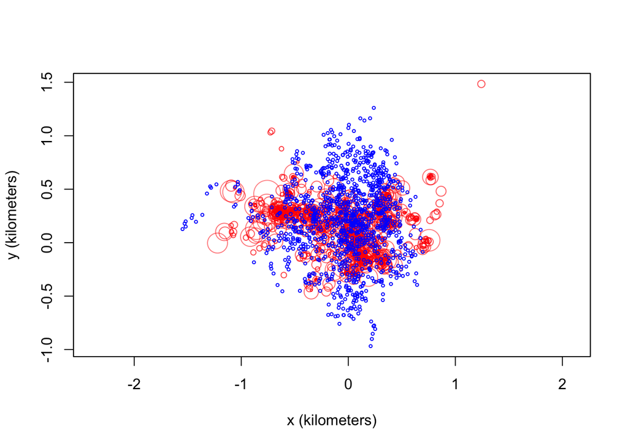

```r
# Simulate from the fitted model, with the original sampling times
SIM <- simulate(FIT, t = DATA$t)

# Visualize the results
plot(list(DATA, SIM), col = c("red", "blue"))
```

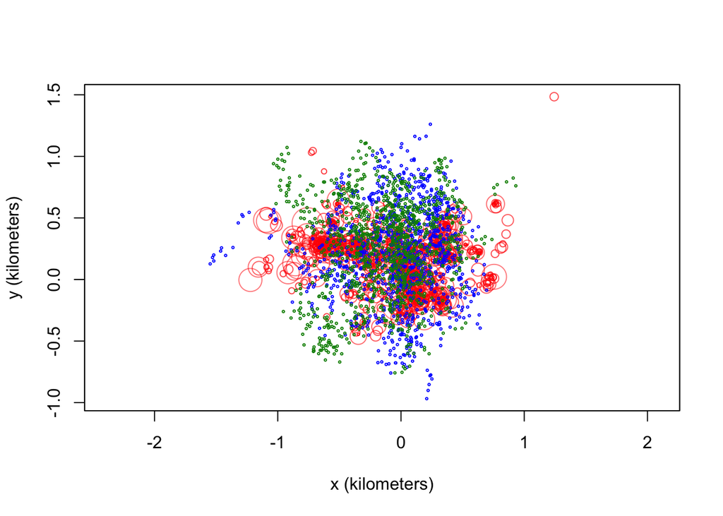

```r
# Draw model parameters from the sampling distribution of the fitted model
FIT2 <- emulate(FIT, fast = TRUE)

# Simulate from the model
SIM2 <- simulate(FIT2, t = DATA$t)

# Visualize the results
plot(list(DATA, SIM, SIM2), col = c("red", "blue", "green4"))
```

Now, if we wanted to fill in the gaps in her sampling data based on a potential trajectory, we could use a simulation that is informed both by her known location points and the movement model that describes her movement.

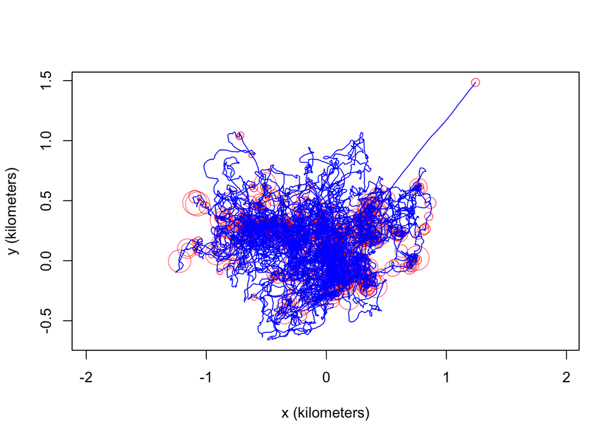

```r
# Fill in the gaps
SIM3 <- simulate(DATA, CTMM = FIT, dt = 60)  # simulate for every 60 sec (1 min)

# Visualize the results
plot(list(DATA, SIM3), type = c("p", "l"), col = c("red", "blue"))
```

### 6.4 Predict the Most-Likely Path

We will predict Aleja’s most-likely path by interpolating between our known locations, given her best-fit movement model.

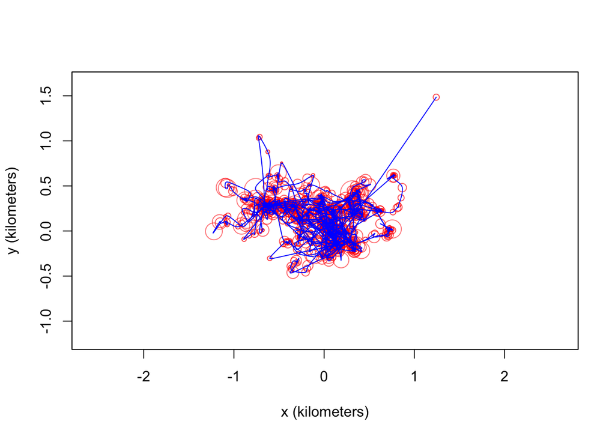

```r
# Generate the most likely path (conditioned on the fitted model)
MLP <- predict(DATA, FIT, dt = 60)

plot(DATA, ylim = c(-1200,1650))
plot(MLP, error = FALSE, type = "l", col = "blue", add = TRUE)
```

```r
# Export the simulations to work with other packages
SIM_EXPORT <- simulate(DATA, CTMM = FIT, complete = TRUE)

EXPORT <- SpatialPoints.telemetry(SIM_EXPORT)  # we can export this to other formats

class(EXPORT)  # `SpatialPoints` object for `sp` package
```

```
## [1] "SpatialPoints"
## attr(,"package")
## [1] "sp"
```

```r
# Different formats/object types allow us to work with our data in other packages
mapview::mapView(EXPORT, alpha = 0.45)
```

[interactive chart not shown]

A combination of the true location data and locations generated from 1 simulation for Aleja.

## 7 Key functions reference

| Function | Package | Purpose |
| --- | --- | --- |
| `predict.ctmm()` or `predict()` | `ctmm` | Predict animal locations from a continuous-time movement model |
| `simulate()` | `ctmm` | Simulate animal locations and tracks from a continuous-time movement model (and conditioned on data, if provided) |
| `emulate()` | `ctmm` | Generate random model-fit statistics from the sampling distribution of a continuous-time movement model and given sampling schedule |

*Next: **Day 5 — Behavior Analysis Part 2** — We will continue our exploration of movement behaviors through behavioral classification with Hidden Markov Models (HMM). We will also walk through how remote sensing data can be incorporated into our analyses, including how to account for issues remotely-sensed data, such as GPS location error.*